# nat: The Neuroanatomy Toolbox for R

Ev Berger-Wolf

2023-02-02

## Final Project: The Neuroanatomy Toolbox (nat) Package

The `nat` package is the core of the “natverse”, a series of packages crucial for neuroanatomical visualization in R. It is highly effective for examining the structure of connectivity of neuronal circuits in various species.

```r
# Setting up libraries
library(nat)
library(rgl)
knitr::knit_hooks$set(webgl = hook_webgl)
```

#### Introduction:

`nat` creates 2 new classes of objects (aside from previous classes, such as `numeric`, `character`, etc.):

- `neuron`: individual neuron objects (see below)
- `neuronlist`: list of neuron objects

```r
## Let's load some  example data:
data("Cell07PNs") #olfactory projection neurons from https://doi.org/10.1016/j.cell.2007.01.040
class(Cell07PNs) #neuronlist (nat) and list (base R)
```

```
## [1] "neuronlist" "list"
```

Because neuronlists are also lists, we can apply some functions to them that we can to lists.

```r
length(Cell07PNs) #number of objects (neurons) in this dataset
```

```
## [1] 40
```

We can also index them similarly.

```r
class(Cell07PNs[[1]]) #neuron objects are also lists
```

```
## [1] "neuron" "list"
```

#### Neurons:

Neuron objects have numerous fields. The most important fields are the following:

- `d`: a data frame object describing the x,y,z positions of each of the nodes (projections) of the neuron and the diameter (w) of the projection
- `NumPoints`: number of points in general
- `StartPoint`, `BranchPoints`, `EndPoints`: all of the neuron’s nodes
- `SegList`: Vertex indices of the neuron’s segments

Let’s pull out the first `neuron` in the `neuronlist`.

```r
neur1 <- Cell07PNs[[1]]

# We can look at a summary of the neuron using summary.neuron (masked as summary)
summary(neur1)
```

```
##   root nodes segments branchpoints endpoints cable.length
## 1    1   180       33           16        18     297.1763
```

#### Neuronlists:

- Primarily store all of the neurons in a dataset/subset.
- Can have an optional attached `data.frame` containing additional information about each of the neurons in the list, called metadata
- We can extract the metadata using `as.data.frame()`

```r
meta_data <- as.data.frame(Cell07PNs)
head(meta_data) #gives us a sense of the qualities we can subset by
```

```
##         Brain RegistrationScore Notes Glomerulus Batch Directory Traced
## EBH11R EBH11R                 4              DA1   PN2    unsure    yes
## EBH20L EBH20L                 4              DL3   PN2   unsure2    yes
## EBH20R EBH20R                 4              DA1   PN2   unsure2    yes
## EBI12L EBI12L                 4              DA1   PN2   unsure3    yes
## EBI22R EBI22R                 4              DL3   PN2   unsure3    yes
## EBJ23L EBJ23L                 4              DL3   PN2   unsure4    yes
##        Scored.By Sex Include     ID HaveWarp HaveAsc
## EBH11R       ACH   M         EBH11R     TRUE    TRUE
## EBH20L       ACH             EBH20L     TRUE    TRUE
## EBH20R       ACH   M         EBH20R     TRUE    TRUE
## EBI12L       ACH   F         EBI12L     TRUE    TRUE
## EBI22R       ACH             EBI22R     TRUE    TRUE
## EBJ23L       ACH             EBJ23L     TRUE    TRUE
##                                                 TraceFile AscBatch Status
## EBH11R /GD/projects/PN2/TransformedTraces/DA1/EBH11R.tasc      New
## EBH20L /GD/projects/PN2/TransformedTraces/DL3/EBH20L.tasc      New
## EBH20R /GD/projects/PN2/TransformedTraces/DA1/EBH20R.tasc      New
## EBI12L /GD/projects/PN2/TransformedTraces/DA1/EBI12L.tasc      New
## EBI22R /GD/projects/PN2/TransformedTraces/DL3/EBI22R.tasc      New
## EBJ23L /GD/projects/PN2/TransformedTraces/DL3/EBJ23L.tasc      New
##        GlomSeq NumNAs MBP1 MBP2 LHBP PNType Seq nTrees StartPoint
## EBH11R       1      0   34   48   75    iPN  13      1          1
## EBH20L       1      0   29   29   77    iPN  15      1          1
## EBH20R       2      0   24   80  147    iPN  16      1          1
## EBI12L       3      0   29   59   89    iPN  18      1          1
## EBI22R       2      0   34   34   56    iPN  20      1          1
## EBJ23L       3      0   23   23   52    iPN  21      1          1
##                  CreatedAt
## EBH11R 2006-01-17 15:21:14
## EBH20L 2006-01-17 15:21:14
## EBH20R 2006-01-17 15:21:14
## EBI12L 2006-01-17 15:21:15
## EBI22R 2006-01-17 15:21:15
## EBJ23L 2006-01-17 15:21:15
##                                                                                             WarpFile
## EBH11R  /GD/projects/PN2/allreg/warp/unsure/average-goodbrains_EBH11R101_warp_m0g40c4e1e-1x16r3.list
## EBH20L /GD/projects/PN2/allreg/warp/unsure2/average-goodbrains_EBH20L101_warp_m0g40c4e1e-1x16r3.list
## EBH20R /GD/projects/PN2/allreg/warp/unsure2/average-goodbrains_EBH20R101_warp_m0g40c4e1e-1x16r3.list
## EBI12L /GD/projects/PN2/allreg/warp/unsure3/average-goodbrains_EBI12L101_warp_m0g40c4e1e-1x16r3.list
## EBI22R /GD/projects/PN2/allreg/warp/unsure3/average-goodbrains_EBI22R101_warp_m0g40c4e1e-1x16r3.list
## EBJ23L /GD/projects/PN2/allreg/warp/unsure4/average-goodbrains_EBJ23L101_warp_m0g40c4e1e-1x16r3.list
```

Using metadata to index:

```r
# Let's say we want to know all of the glomeruli represented in the dataset
with(Cell07PNs, table(Glomerulus)) #shows number of neurons in each glomerulus
```

```
## Glomerulus
##  DA1  DL3 DP1m VA1d
##   11   10    8   11
```

```r
# Now we can subet neurons based on their glomerulus
va1d_n <- subset(Cell07PNs, Glomerulus=="VA1d") #new sub-neuronlist of neurons in glomerulus VA1d

# If we want a summary of the meta data, rather than the neuronlist:
summary(Cell07PNs[,]) #[,] accesses the data frame without as.data.frame()
```

```
##     Brain           RegistrationScore    Notes           Glomerulus
##  Length:40          Min.   :4         Length:40          DA1 :11
##  Class :character   1st Qu.:4         Class :character   DL3 :10
##  Mode  :character   Median :4         Mode  :character   DP1m: 8
##                     Mean   :4                            VA1d:11
##                     3rd Qu.:4
##                     Max.   :4
##
##              Batch      Directory  Traced   Scored.By  Sex    Include
##  PN1            :18          :30   yes:22   ACH  :21    :19   :40
##  PN2            :10   DP1m   : 1      :18   CJP  : 1   F:14
##  ChrisAprImages3: 3   unsure : 1            GSXEJ:18   M: 7
##  1027_DM1DM2VA1d: 2   unsure2: 2
##  ChrisAprImages2: 2   unsure3: 3
##  ChrisDecImages2: 1   unsure4: 2
##  (Other)        : 4   unsure5: 1
##        ID     HaveWarp       HaveAsc         TraceFile         AscBatch
##  EBH11R : 1   Mode:logical   Mode:logical   Length:40             : 9
##  EBH20L : 1   TRUE:40        TRUE:40        Class :character   New:13
##  EBH20R : 1                                 Mode  :character   Old:18
##  EBI12L : 1
##  EBI22R : 1
##  EBJ23L : 1
##  (Other):34
##     Status             GlomSeq           NumNAs       MBP1
##  Length:40          Min.   : 1.000   Min.   :0   Min.   :  4.00
##  Class :character   1st Qu.: 3.000   1st Qu.:0   1st Qu.:  9.00
##  Mode  :character   Median : 5.500   Median :0   Median : 19.00
##                     Mean   : 5.575   Mean   :0   Mean   : 53.77
##                     3rd Qu.: 8.000   3rd Qu.:0   3rd Qu.: 37.25
##                     Max.   :11.000   Max.   :0   Max.   :235.00
##
##       MBP2             LHBP           PNType               Seq
##  Min.   :  7.00   Min.   : 33.00   Length:40          Min.   : 13.0
##  1st Qu.: 31.25   1st Qu.: 62.75   Class :character   1st Qu.: 36.5
##  Median : 54.00   Median : 89.50   Mode  :character   Median :146.5
##  Mean   :101.42   Mean   :158.57                      Mean   :126.4
##  3rd Qu.: 97.00   3rd Qu.:140.25                      3rd Qu.:179.8
##  Max.   :685.00   Max.   :945.00                      Max.   :244.0
##
##      nTrees    StartPoint    CreatedAt                        WarpFile
##  Min.   :1   Min.   :1.0   Min.   :2006-01-16 20:29:40.00   Length:40
##  1st Qu.:1   1st Qu.:1.0   1st Qu.:2006-01-17 15:21:17.00   Class :character
##  Median :1   Median :1.0   Median :2006-01-17 15:22:28.00   Mode  :character
##  Mean   :1   Mean   :1.1   Mean   :2006-01-17 14:53:57.81
##  3rd Qu.:1   3rd Qu.:1.0   3rd Qu.:2006-01-17 15:22:58.00
##  Max.   :1   Max.   :2.0   Max.   :2006-01-17 15:23:11.00
##
```

#### Plotting neurons:

We can plot an individual neuron:

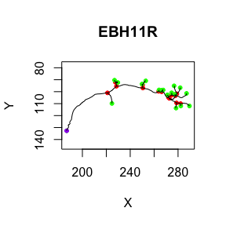

```r
plot(neur1) #purple node = root/soma of the neuron, red nodes = branch points, green nodes = end points
```

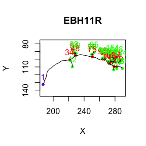

```r
plot(neur1, WithText=T) #we can label nodes based on their PointNo index from the data.frame d (see above)
```

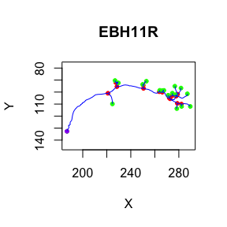

```r
plot(neur1, col="blue") #we can change the color of a neuron's axon using col
```

We can also plot multiple neurons:

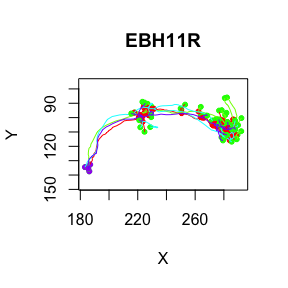

```r
plot(Cell07PNs[1:4]) #plots first 4 neurons from the neuronlist
```

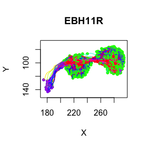

```r
plot(Cell07PNs) #plots all of the neurons
```

We can use subsetting to highlight a specific quality of the neurons:

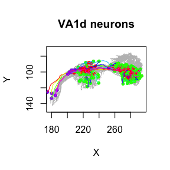

```r
plot(Cell07PNs, subset=Glomerulus!="VA1d", col='grey',
     WithNodes=F, main="VA1d neurons") #main=title, removes nodes, plots all but the VA1d neurons in grey
plot(Cell07PNs, subset=Glomerulus=="VA1d", add=TRUE) #adds the Va1d neurons to the plot (superimposes using add=TRUE)
```

#### 3D Plots:

3D plotting is super important in anatomical mapping, since our bodies (specifically our brains) do not exist on a 2D plane.

- `nat` uses the `rgl` package to plot 3D models of the neurons (remember that the neuron has z coordinates too!).

You can drag the neuron below around and zoom in and out.

```r
clear3d()
plot3d(neur1, col='blue')
```

[interactive chart not shown]

You can also plot multiple neurons on a 3D plot.

```r
plot3d(Cell07PNs, subset=grepl("^D", Glomerulus), #subset all neurons with glomeruli starting with "D"
            col=Glomerulus, lwd=2, WithNodes=FALSE) #color by glomerulus, lwd = line weight
```

[interactive chart not shown]

Access the nat package [here](https://github.com/natverse/nat).  
Information obtained from https://natverse.org/nat/articles/neurons-intro.html.